# Gaussian Elimination and LU Decomposition

Biostat/Biomath M257

Author

Dr. Hua Zhou @ UCLA

Published

May 13, 2025

System information (for reproducibility):

```julia
versioninfo()
```

```
Julia Version 1.11.5
Commit 760b2e5b739 (2025-04-14 06:53 UTC)
Build Info:
  Official https://julialang.org/ release
Platform Info:
  OS: macOS (arm64-apple-darwin24.0.0)
  CPU: 12 × Apple M2 Max
  WORD_SIZE: 64
  LLVM: libLLVM-16.0.6 (ORCJIT, apple-m2)
Threads: 8 default, 0 interactive, 4 GC (on 8 virtual cores)
Environment:
  JULIA_NUM_THREADS = 8
  JULIA_EDITOR = code
```

Load packages:

```julia
using Pkg

Pkg.activate(pwd())
Pkg.instantiate()
Pkg.status()
```

```
Status `~/Documents/github.com/ucla-biostat-257/2025spring/slides/11-gelu/Project.toml`
  [37e2e46d] LinearAlgebra v1.11.0
```

```
  Activating project at `~/Documents/github.com/ucla-biostat-257/2025spring/slides/11-gelu`
```

- Goal: solve linear equation
  $$\mathbf{A} \mathbf{x} = \mathbf{b}.$$
  For simplicity we consider a square matrix $\mathbf{A} \in \mathbb{R}^{n \times n}$.
- History: Chinese mathematical text [The Nine Chapters on the Mathematical Art](https://en.wikipedia.org/wiki/The_Nine_Chapters_on_the_Mathematical_Art), Issac Newton and Carl Friedrich Gauss.

[figure not shown]

- A [toy example](https://en.wikipedia.org/wiki/Gaussian_elimination#Example_of_the_algorithm).

```julia
A = [2.0 1.0 -1.0; -3.0 -1.0 2.0; -2.0 1.0 2.0]
```

```
3×3 Matrix{Float64}:
  2.0   1.0  -1.0
 -3.0  -1.0   2.0
 -2.0   1.0   2.0
```

```julia
b = [8.0, -11.0, -3.0]
```

```
3-element Vector{Float64}:
   8.0
 -11.0
  -3.0
```

```julia
# Julia way to solve linear equation
# equivalent to `solve(A, b)` in R
A \ b
```

```
3-element Vector{Float64}:
  2.0000000000000004
  2.9999999999999996
 -0.9999999999999991
```

What happens when we call `A \ b` to solve a linear equation?

## 1 Elementary operator matrix

- **Elementary operator matrix** is the identity matrix with the 0 in position $(j,k)$ replaced by $c$
  $$\mathbf{E}_{jk}(c) = \begin{pmatrix}
  1 & & \\
  & \ddots & \\
  & & 1 & \\
  & & & \ddots & \\
  & & c & & 1 & \\
  & & & & & \ddots \\
  & & & & & & 1
  \end{pmatrix} = \mathbf{I} + c \mathbf{e}_j \mathbf{e}_k^T.$$
- $\mathbf{E}_{jk}(c)$ is unit triangular, full rank, and its inverse is
  $$\mathbf{E}_{jk}^{-1}(c) = \mathbf{E}_{jk}(-c).$$
- $\mathbf{E}_{jk}(c)$ left-multiplies an $n \times m$ matrix $\mathbf{X}$ effectively replace its $j$-th row $\mathbf{x}_{j\cdot}$ by $c \mathbf{x}_{k \cdot} + \mathbf{x}_{j \cdot}$
  $$\mathbf{E}_{jk}(c) \times \mathbf{X} = \mathbf{E}_{jk}(c) \times \begin{pmatrix}
  & & \\
  \cdots & \mathbf{x}_{k\cdot} & \cdots \\
  & & \\
  \cdots & \mathbf{x}_{j\cdot} & \cdots \\
  & &
  \end{pmatrix} = \begin{pmatrix}
  & & \\
  \cdots & \mathbf{x}_{k\cdot} & \cdots \\
  & & \\
  \cdots & c \mathbf{x}_{k\cdot} + \mathbf{x}_{j\cdot} & \cdots \\
  & &
  \end{pmatrix}.$$
  $2m$ flops.
- Gaussian elimination applies a sequence of elementary operator matrices to transform the linear system $\mathbf{A} \mathbf{x} = \mathbf{b}$ to an upper triangular system
  $$\begin{eqnarray*}
  \mathbf{E}_{n,n-1}(c_{n,n-1}) \cdots \mathbf{E}_{21}(c_{21}) \mathbf{A} \mathbf{x} &=& \mathbf{E}_{n,n-1}(c_{n,n-1}) \cdots \mathbf{E}_{21}(c_{21}) \mathbf{b} \\
  \mathbf{U} \mathbf{x} &=& \mathbf{b}_{\text{new}}.
  \end{eqnarray*}$$

  Column 1:

```julia
E21 = [1.0 0.0 0.0; 1.5 1.0 0.0; 0.0 0.0 1.0]
```

```
3×3 Matrix{Float64}:
 1.0  0.0  0.0
 1.5  1.0  0.0
 0.0  0.0  1.0
```

```julia
# zero (2, 1) entry
E21 * A
```

```
3×3 Matrix{Float64}:
  2.0  1.0  -1.0
  0.0  0.5   0.5
 -2.0  1.0   2.0
```

```julia
E31 = [1.0 0.0 0.0; 0.0 1.0 0.0; 1.0 0.0 1.0]
```

```
3×3 Matrix{Float64}:
 1.0  0.0  0.0
 0.0  1.0  0.0
 1.0  0.0  1.0
```

```julia
# zero (3, 1) entry
E31 * E21 * A
```

```
3×3 Matrix{Float64}:
 2.0  1.0  -1.0
 0.0  0.5   0.5
 0.0  2.0   1.0
```

```
Column 2:
```

```julia
E32 = [1.0 0.0 0.0; 0.0 1.0 0.0; 0.0 -4.0 1.0]
```

```
3×3 Matrix{Float64}:
 1.0   0.0  0.0
 0.0   1.0  0.0
 0.0  -4.0  1.0
```

```julia
# zero (3, 2) entry
E32 * E31 * E21 * A
```

```
3×3 Matrix{Float64}:
 2.0  1.0  -1.0
 0.0  0.5   0.5
 0.0  0.0  -1.0
```

## 2 Gauss transformations

- For the first column,
  $$\mathbf{M}_1 = \mathbf{E}_{n1}(c_{n1}) \cdots \mathbf{E}_{31}(c_{31}) \mathbf{E}_{21}(c_{21}) = \begin{pmatrix}
  1 & \\
  c_{21} & \\
  & \ddots & \\
  c_{n1} & & 1
  \end{pmatrix}$$
  For the $k$-th column,
  $$\mathbf{M}_k = \mathbf{E}_{nk}(c_{nk}) \cdots \mathbf{E}_{k+1,k}(c_{k+1,k}) = \begin{pmatrix}
  1 & \\
  & \ddots \\
  & & 1 & \\
  & & c_{k+1,k} & 1\\
  & & \vdots & & \ddots \\
  & & c_{n,k} & & & 1
  \end{pmatrix}.$$
- $\mathbf{M}_1, \ldots, \mathbf{M}_{n-1}$ are called the **Gauss transformations**.

```julia
M1 = E31 * E21
```

```
3×3 Matrix{Float64}:
 1.0  0.0  0.0
 1.5  1.0  0.0
 1.0  0.0  1.0
```

```julia
M2 = E32
```

```
3×3 Matrix{Float64}:
 1.0   0.0  0.0
 0.0   1.0  0.0
 0.0  -4.0  1.0
```

- Gauss transformations $\mathbf{M}_k$ are unit triangular, full rank, with inverse
  $$\mathbf{M}_k^{-1} = \mathbf{E}_{k+1,k}^{-1}(c_{k+1,k}) \cdots \mathbf{E}_{nk}^{-1}(c_{nk}) = \begin{pmatrix}
  1 & \\
  & \ddots \\
  & & 1 & \\
  & & - c_{k+1,k}\\
  & & \vdots & & \ddots \\
  & & - c_{n,k} & & & 1
  \end{pmatrix}.$$

```julia
inv(M1)
```

```
3×3 Matrix{Float64}:
  1.0  0.0  0.0
 -1.5  1.0  0.0
 -1.0  0.0  1.0
```

```julia
inv(M2)
```

```
3×3 Matrix{Float64}:
 1.0  0.0  0.0
 0.0  1.0  0.0
 0.0  4.0  1.0
```

## 3 LU decomposition

Gaussian elimination does
$$\mathbf{M}_{n-1} \cdots \mathbf{M}_1 \mathbf{A} = \mathbf{U}.$$
Let
$$\begin{equation*}
\mathbf{L} = \mathbf{M}_1^{-1} \cdots \mathbf{M}_{n-1}^{-1} = \begin{pmatrix}
1 & & & & \\
\,- c_{21} & \ddots & & & \\
& & 1 & & \\
\, - c_{k+1,1} & & - c_{k+1,k} & & \\
& & \vdots & & \ddots \\
\,- c_{n1} & & - c_{nk} & & & 1
\end{pmatrix}.
\end{equation*}$$
Thus we have the **LU decomposition**
$$\mathbf{A} = \mathbf{L} \mathbf{U},$$
where $\mathbf{L}$ is unit lower triangular and $\mathbf{U}$ is upper triangular.

```julia
# collect negative multipliers into a unit lower triangular matrix
L = [1 0 0; -3/2 1 0; -1 4 1]
```

```
3×3 Matrix{Float64}:
  1.0  0.0  0.0
 -1.5  1.0  0.0
 -1.0  4.0  1.0
```

```julia
# upper triangular matrix after Gaussian elimination
U = [2 1 -1; 0 1/2 1/2; 0 0 -1]
```

```
3×3 Matrix{Float64}:
 2.0  1.0  -1.0
 0.0  0.5   0.5
 0.0  0.0  -1.0
```

```julia
# recovers original matrix
L * U
```

```
3×3 Matrix{Float64}:
  2.0   1.0  -1.0
 -3.0  -1.0   2.0
 -2.0   1.0   2.0
```

- The whole LU algorithm is done in place, i.e., $\mathbf{A}$ is overwritten by $\mathbf{L}$ and $\mathbf{U}$.
- LU decomposition exists if the principal sub-matrix $\mathbf{A}[1:k, 1:k]$ is non-singular for $k=1,\ldots,n-1$.
- If the LU decomposition exists and $\mathbf{A}$ is non-singular, then the LU decmpositon is unique and
  $$\det(\mathbf{A}) = \det(\mathbf{L}) \det(\mathbf{U}) = \prod_{k=1}^n u_{kk}.$$
- The LU decomposition costs
  $$2(n-1)^2 + 2(n-2)^2 + \cdots + 2 \cdot 1^2 \approx \frac 23 n^3 \quad \text{flops}.$$

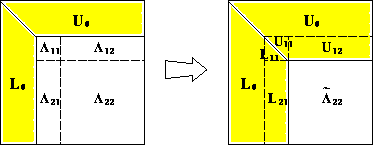

- Actual implementations can differ: outer product LU ($kij$ loop), block outer product LU (higher level-3 fraction), Crout’s algorithm ($jki$ loop).
- Given LU decomposition $\mathbf{A} = \mathbf{L} \mathbf{U}$, solving $(\mathbf{L} \mathbf{U}) \mathbf{x} = \mathbf{b}$ for one right hand side costs $2n^2$ flops:
  - One forward substitution ($n^2$ flops) to solve
    $$\mathbf{L} \mathbf{y} = \mathbf{b}$$
  - One back substitution ($n^2$ flops) to solve
    $$\mathbf{U} \mathbf{x} = \mathbf{y}$$
- Therefore to solve $\mathbf{A} \mathbf{x} = \mathbf{b}$ via LU, we need a total of
  $$\frac 23 n^3 + 2n^2 \quad \text{flops}.$$
- If there are multiple right hand sides, LU only needs to be done once.

## 4 Matrix inversion

- For matrix inversion, we need to solve $\mathbf{A} \mathbf{X} = \mathbf{I}$, or $\mathbf{A} \mathbf{x}_i = \mathbf{e}_i$ for $i=1,\ldots,n$. There are $n$ right hand sides $\mathbf{e}_1, \ldots, \mathbf{e}_n$. Naively, we may need $\frac 23 n^3 + 2n^3$ flops. But taking advantage of 0s reduces the second term $2n^3$ to $\frac 43 n^3$.
- So **matrix inversion via LU** costs
  $$\frac 23 n^3 + \frac 43 n^3 = 2n^3 \quad \text{flops}.$$
  This is 3x more expensive than just solving one equation.
- **No inversion mentality**:

> **Whenever we see matrix inverse, we should think in terms of solving linear equations.**
- We do not compute matrix inverse unless
  1. it is necessary to compute standard errors
  2. number of right hand sides is much larger than $n$
  3. $n$ is small

## 5 Pivoting

- Let
  $$\mathbf{A} = \begin{pmatrix}
  0 & 1 \\
  1 & 0 \\
  \end{pmatrix}.$$
  Is there a solution to $\mathbf{A} \mathbf{x} = \mathbf{b}$ for an arbitrary $\mathbf{b}$? Does GE/LU work for $\mathbf{A}$?
- What if, during LU procedure, the **pivot** $a_{kk}$ is 0 or nearly 0 due to underflow?  
  Solution: pivoting.
- **Partial pivoting**: before zeroing the $k$-th column, the row with $\max_{i=k}^n |a_{ik}|$ is moved into the $k$-th row.
- LU with partial pivoting yields
  $$\mathbf{P} \mathbf{A} = \mathbf{L} \mathbf{U},$$
  where $\mathbf{P}$ is a permutation matrix, $\mathbf{L}$ is unit lower triangular with $|\ell_{ij}| \le 1$, and $\mathbf{U}$ is upper triangular.
- Complete pivoting: Do both row and column interchanges so that the largest entry in the sub matrix `A[k:n, k:n]` is permuted to the $(k,k)$-th entry. This yields the decomposition
  $$\mathbf{P} \mathbf{A} \mathbf{Q} = \mathbf{L} \mathbf{U},$$
  where $|\ell_{ij}| \le 1$.
- LU decomposition with partial pivoting is the most commonly used methods for solving **general** linear systems. Complete pivoting is the most stable but costs more computation. Partial pivoting is stable most of times.

## 6 LAPACK and Julia implementation

- LAPACK: [?getrf](http://www.netlib.org/lapack/explore-html/dd/d9a/group__double_g_ecomputational_ga0019443faea08275ca60a734d0593e60.html#ga0019443faea08275ca60a734d0593e60) does $\mathbf{P} \mathbf{A} = \mathbf{L} \mathbf{U}$ (LU decomposition with partial pivoting) in place.
- R: `solve()` implicitly performs LU decomposition (wrapper of LAPACK routine `dgesv`). `solve()` allows specifying a single or multiple right hand sides. If none, it computes the matrix inverse. The `matrix` package contains `lu()` function that outputs `L`, `U`, and `pivot`.
- Julia:
  - LinearAlgebra.lu.
  - LinearAlgebra.lu!. In-place version. Input matrix gets overwritten with L and U.
  - Or call LAPACK wrapper function getrf! directly.
  - Other LU-related LAPACK wrapper functions: [gesv](https://docs.julialang.org/en/v1/stdlib/LinearAlgebra/#LinearAlgebra.LAPACK.gesv!), [gesvx](https://docs.julialang.org/en/v1/stdlib/LinearAlgebra/#LinearAlgebra.LAPACK.gesvx!), [trtri](https://docs.julialang.org/en/v1/stdlib/LinearAlgebra/#LinearAlgebra.LAPACK.trtri!) (inverse of triangular matrix), [trtrs](https://docs.julialang.org/en/v1/stdlib/LinearAlgebra/#LinearAlgebra.LAPACK.trtrs!).

```julia
A
```

```
3×3 Matrix{Float64}:
  2.0   1.0  -1.0
 -3.0  -1.0   2.0
 -2.0   1.0   2.0
```

```julia
using LinearAlgebra

# second argument indicates partial pivoting (default) or not
alu = lu(A)
typeof(alu)
```

```
LU{Float64, Matrix{Float64}, Vector{Int64}}
```

```julia
dump(alu)
```

```
LU{Float64, Matrix{Float64}, Vector{Int64}}
  factors: Array{Float64}((3, 3)) [-3.0 -1.0 2.0; 0.6666666666666666 1.6666666666666665 0.6666666666666667; -0.6666666666666666 0.20000000000000004 0.19999999999999987]
  ipiv: Array{Int64}((3,)) [2, 3, 3]
  info: Int64 0
```

```julia
alu.L
```

```
3×3 Matrix{Float64}:
  1.0       0.0  0.0
  0.666667  1.0  0.0
 -0.666667  0.2  1.0
```

```julia
alu.U
```

```
3×3 Matrix{Float64}:
 -3.0  -1.0      2.0
  0.0   1.66667  0.666667
  0.0   0.0      0.2
```

```julia
alu.p
```

```
3-element Vector{Int64}:
 2
 3
 1
```

```julia
alu.P
```

```
3×3 Matrix{Float64}:
 0.0  1.0  0.0
 0.0  0.0  1.0
 1.0  0.0  0.0
```

```julia
alu.L * alu.U
```

```
3×3 Matrix{Float64}:
 -3.0  -1.0   2.0
 -2.0   1.0   2.0
  2.0   1.0  -1.0
```

```julia
A[alu.p, :]
```

```
3×3 Matrix{Float64}:
 -3.0  -1.0   2.0
 -2.0   1.0   2.0
  2.0   1.0  -1.0
```

```julia
# this is doing two triangular solves, 2n^2 flops
alu \ b
```

```
3-element Vector{Float64}:
  2.0000000000000004
  2.9999999999999996
 -0.9999999999999991
```

```julia
det(A) # this does LU! O(n^3)
```

```
-0.9999999999999993
```

```julia
det(alu) # this is cheap O(n)
```

```
-0.9999999999999993
```

```julia
inv(A) # this does LU! O(n^3)
```

```
3×3 Matrix{Float64}:
  4.0   3.0  -1.0
 -2.0  -2.0   1.0
  5.0   4.0  -1.0
```

```julia
inv(alu) # this is cheap O(n^2)
```

```
3×3 Matrix{Float64}:
  4.0   3.0  -1.0
 -2.0  -2.0   1.0
  5.0   4.0  -1.0
```

## 7 Further reading

- Sections II.5.2 and II.5.3 of [Computational Statistics](http://ucla.worldcat.org/title/computational-statistics/oclc/437345409&referer=brief_results) by James Gentle (2010).
- A definite reference is Chapter 3 of the book [Matrix Computation](http://catalog.library.ucla.edu/vwebv/holdingsInfo?bibId=7122088) by Gene Golub and Charles Van Loan.

[figure not shown]

[figure not shown]